# Predicting March Madness 2020

Ken Harmon

2019 October 05

## NCAARock

NCAA Season Stats: https://www.sports-reference.com/cbb/seasons/

All Tournament Game Results:

From which I can get Seed Expectations From Which I can get each teams PASE

Kenpom Rankings: https://kenpom.com/index.php?s=TeamName

### 2002 to 2019 Games

```r
# Load NCAARock of all games and the differences of season stats
NCAARock <- read.csv( "NCAARock.csv", stringsAsFactor = FALSE )

NCAARock <- NCAARock %>% mutate(result = Fscore - Uscore)

#If you want to see where the NAs are
#sapply(NCAARock, function(x) sum(is.na(x)))
# pull out just the Numeric columns
temp <- NCAARock %>% select(10:52)

#Fill in all of the NAs with the K nearest neighbor
temp <- knnImputation(temp, k = 10, scale = T, meth = "weighAvg", distData = NULL)

#pull of the front columns not in temp
Front <- NCAARock %>% select(1:9)

NCAARock <- cbind(Front,temp)

#binomial the difference in Score
bresult <- ifelse(NCAARock$result > 0, "F", "U")
NCAARock$bresult <- as.factor(bresult)

datatable(NCAARock, extensions = "Responsive",options=list(lengthMenu = c(10,25,68)))
```

|  | Year | Round | Fseed | Favored | Fscore | Useed | Underdog | Uscore | Winner | PAKE.d | PASE.d | G.d | W.d | L.d | W.L..d | SRS.d | SOS.d | CW.d | CL.d | HW.d | HL.d | CW2.d | CL3.d | TmP.d | OppP.d | MP.d | FG.d | FGA.d | FG..d | … |
| --- | --- | --- | --- | --- | --- | --- | --- | --- | --- | --- | --- | --- | --- | --- | --- | --- | --- | --- | --- | --- | --- | --- | --- | --- | --- | --- | --- | --- | --- | --- |
| 1 | 2002 | PI | 16 | Siena | 81 | 16 | Alcorn St. | 77 | Siena | 3.61761253573636 | 3.86733429862306 | 5 | -4 | 9 | -0.205 | 8.54 | 10.47 | -7 | 7 | 1 | 5 | -5 | 2 | 44 | 108 | 79.9028240460995 | -47 | 109 | -0.048 | … |
| 2 | 2002 | 1 | 4 | USC | 89 | 13 | UNC Wilmington | 93 | UNC Wilmington | 2.3 | 1.6 | -1 | -1 | 0 | -0.009 | 10.34 | 8.4 | -2 | 2 | 2 | 0 | 0 | -1 | 254 | 198 | -35 | 125 | 260 | 0.006 | … |
| 3 | 2002 | 1 | 5 | Marquette | 69 | 12 | Tulsa | 71 | Tulsa | -2.4 | -4 | -1 | -1 | 0 | -0.006 | 4.5 | 2.47 | -2 | 0 | 3 | -3 | -5 | 4 | -313 | -359 | -45 | -90 | -175 | -0.004 | … |
| 4 | 2002 | 1 | 12 | Missouri | 93 | 5 | Miami FL | 80 | Missouri | -0.3 | 1.5 | 4 | 0 | 4 | -0.083 | 1.23 | 1.29 | -1 | 1 | 1 | 1 | -1 | 2 | 482 | 454 | 123.578125229767 | 213 | 351 | 0.028 | … |
| 5 | 2002 | 1 | 6 | Gonzaga | 66 | 11 | Wyoming | 73 | Wyoming | 1.8 | 1.6 | 2 | 7 | -5 | 0.169 | 5.28 | -1.98 | 2 | -2 | -1 | -1 | 5 | -4 | 353 | 68 | 90.5695669114085 | 112 | 186 | 0.014 | … |
| 6 | 2002 | 1 | 4 | Kentucky | 83 | 13 | Valparaiso | 68 | Kentucky | 10.2 | 9.9 | -1 | -3 | 2 | -0.07 | 9.77 | 13.23 | -2 | 4 | 1 | 2 | -3 | -1 | -104 | 3 | 38.4313494256459 | 12 | 32 | -0.001 | … |
| 7 | 2002 | 1 | 1 | Kansas | 70 | 16 | Holy Cross | 59 | Kansas | 5.6 | 0.3 | 4 | 15 | -11 | 0.347 | 26 | 14.45 | 7 | -5 | 4 | -3 | 5 | -7 | 1282 | 797 | 172.92008756945 | 565 | 776 | 0.1 | … |
| 8 | 2002 | 1 | 2 | Oregon | 81 | 15 | Montana | 62 | Oregon | 7.1 | 6.2 | 4 | 10 | -6 | 0.227 | 23.87 | 8.64 | 7 | -3 | 8 | -4 | 1 | -1 | 776 | 275 | 157.669685576735 | 254 | 412 | 0.032 | … |
| 9 | 2002 | 1 | 7 | Wake Forest | 83 | 10 | Pepperdine | 74 | Wake Forest | -3.4 | -4 | 3 | -1 | 4 | -0.092 | 6.66 | 6.92 | -4 | 6 | 2 | 2 | -2 | 1 | 270 | 301 | 114.284406250728 | 95 | 104 | 0.023 | … |
| 10 | 2002 | 1 | 8 | Stanford | 84 | 9 | Western Kentucky | 68 | Stanford | -4.1 | -6 | -2 | -8 | 6 | -0.208 | 6.57 | 9.31 | -1 | 5 | -4 | 3 | -3 | 2 | -71 | 111 | -80 | -54 | -61 | -0.014 | … |

[output cut: 1173 more lines]

## Train and Test

```r
# Get the number of observations
n_obs <- nrow(NCAARock)

# Shuffle row indices: permuted_rows
permuted_rows <- sample(n_obs)

# Randomly order data: Sonar
NCAA_shuffled <- NCAARock[permuted_rows, ]

# Identify row to split on: split
split <- round(n_obs * 0.6)

# Create train
train <- NCAA_shuffled[1:split, ]

# Create test
test <- NCAA_shuffled[(split + 1):n_obs, ]

nrow(train)/nrow(NCAARock)
```

```
## [1] 0.6001691
```

## Logistic Regression

```r
# Fit glm model: model
model <- glm(bresult ~ ., family = "binomial", train %>% select(10:51,53))

# Predict on test: p
p <- predict(model, test, type = "response")
```

### Confusion Matrix

```r
# If p exceeds threshold of 0.5, M else R: m_or_r
F_or_U <- ifelse(p < .5, "F", "U")


# Convert to factor: p_class
p_class <- factor(F_or_U, levels = levels(test[["bresult"]]))

# Create confusion matrix
confusionMatrix(p_class, test$bresult)
```

```
## Confusion Matrix and Statistics
##
##           Reference
## Prediction   F   U
##          F 331  38
##          U  23  81
##
##                Accuracy : 0.871
##                  95% CI : (0.8374, 0.8999)
##     No Information Rate : 0.7484
##     P-Value [Acc > NIR] : 3.461e-11
##
##                   Kappa : 0.6426
##
##  Mcnemar's Test P-Value : 0.07305
##
##             Sensitivity : 0.9350
##             Specificity : 0.6807
##          Pos Pred Value : 0.8970
##          Neg Pred Value : 0.7788
##              Prevalence : 0.7484
##          Detection Rate : 0.6998
##    Detection Prevalence : 0.7801
##       Balanced Accuracy : 0.8079
##
##        'Positive' Class : F
##
```

## Trees

Build a classification tree

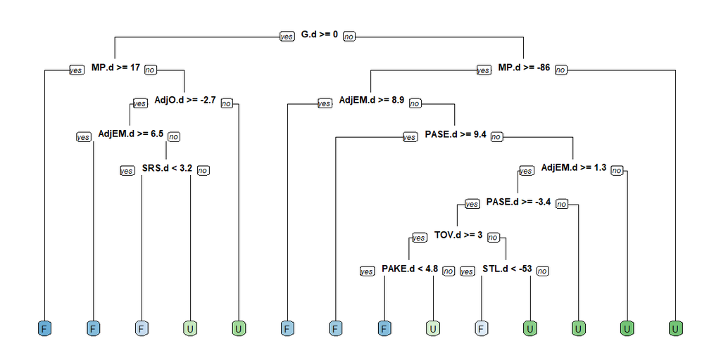

```r
# Create the model
pred_model <- rpart(formula = bresult ~ ., data = NCAARock %>% select(1:3,6,10:51,53), method = "class", model=TRUE)

# Display the results
rpart.plot(x = pred_model, yesno = 2, type = 0, extra = 0)
```

Train/test split

```r
# Total number of rows in the NCAA data frame
n <- nrow(NCAARock)

# Number of rows for the training set (80% of the dataset)
n_train <- round(.8 * n)

# Create a vector of indices which is an 80% random sample
set.seed(123)
train_indices <- sample(1:n, n_train)

# Subset the NCAA data frame to training indices only
NCAA_train <- NCAARock[train_indices, ]

# Exclude the training indices to create the test set
NCAA_test <- NCAARock[-train_indices, ]
```

Train a classification tree model

```r
# Train the model (to predict 'bresult')
NCAA_model <- rpart(formula = bresult ~ ., data = NCAA_train %>% select(1:3,6,10:51,53), method = "class", model = TRUE)

# Look at the model output
print(NCAA_model)
```

```
## n= 946
##
## node), split, n, loss, yval, (yprob)
##       * denotes terminal node
##
##  1) root 946 225 F (0.76215645 0.23784355)
##    2) MP.d>=-46.02245 797 102 F (0.87202008 0.12797992)
##      4) G.d>=0.5 573  27 F (0.95287958 0.04712042) *
##      5) G.d< 0.5 224  75 F (0.66517857 0.33482143)
##       10) AdjEM.d>=7.335 98  15 F (0.84693878 0.15306122) *
##       11) AdjEM.d< 7.335 126  60 F (0.52380952 0.47619048)
##         22) PASE.d>=1.55 48  11 F (0.77083333 0.22916667) *
##         23) PASE.d< 1.55 78  29 U (0.37179487 0.62820513)
##           46) G.d>=-0.5 47  23 F (0.51063830 0.48936170)
##             92) SRS.d< 3.305 29  10 F (0.65517241 0.34482759) *
##             93) SRS.d>=3.305 18   5 U (0.27777778 0.72222222) *
##           47) G.d< -0.5 31   5 U (0.16129032 0.83870968) *
##    3) MP.d< -46.02245 149  26 U (0.17449664 0.82550336) *
```

Compute confusion matrix

```r
# Generate predicted classes using the model object

class_prediction <- predict(object = NCAA_model, newdata = NCAA_test, type = "class")

# Calculate the confusion matrix for the test set
confusionMatrix(data = class_prediction, reference = NCAA_test$bresult)
```

```
## Confusion Matrix and Statistics
##
##           Reference
## Prediction   F   U
##          F 154  24
##          U  14  45
##
##                Accuracy : 0.8397
##                  95% CI : (0.7866, 0.884)
##     No Information Rate : 0.7089
##     P-Value [Acc > NIR] : 2.079e-06
##
##                   Kappa : 0.5942
##
##  Mcnemar's Test P-Value : 0.1443
##
##             Sensitivity : 0.9167
##             Specificity : 0.6522
##          Pos Pred Value : 0.8652
##          Neg Pred Value : 0.7627
##              Prevalence : 0.7089
##          Detection Rate : 0.6498
##    Detection Prevalence : 0.7511
##       Balanced Accuracy : 0.7844
##
##        'Positive' Class : F
##
```

Compare models with a different splitting criterion

```r
# Train a gini-based model
NCAA_model1 <- rpart(formula = bresult ~ .,
                       data = NCAA_train %>% select(1:3,6,10:51,53),
                       method = "class",
                       parms = list(split = "gini"), model = TRUE)

# Train an information-based model
NCAA_model2 <- rpart(formula = bresult ~ .,
                       data = NCAA_train %>% select(1:3,6,10:51,53),
                       method = "class",
                       parms = list(split = "information"), model = TRUE)

# Generate predictions on the validation set using the gini model
pred1 <- predict(object = NCAA_model1,
             newdata = NCAA_test %>% select(1:3,6,10:51,53),
             type = "class")

# Generate predictions on the validation set using the information model
pred2 <- predict(object = NCAA_model2,
             newdata = NCAA_test %>% select(1:3,6,10:51,53),
             type = "class")

# Compare classification error
ce(actual = NCAA_test$bresult,
   predicted = pred1)
```

```
## [1] 0.1603376
```

```r
ce(actual = NCAA_test$bresult,
   predicted = pred2)
```

```
## [1] 0.1687764
```

## Regression Trees

Split the Data

```r
# Set seed and create assignment
set.seed(1)
assignment <- sample(1:3, size = nrow(NCAARock), prob = c(.7,.15,.15), replace = TRUE)

# Create a train, validation and tests from the original data frame
NCAA_train <- NCAARock[assignment == 1, ]    # subset NCAA to training indices only
NCAA_valid <- NCAARock[assignment == 2, ]  # subset NCAA to validation indices only
NCAA_test <- NCAARock[assignment == 3, ]   # subset NCAA to test indices only
```

Train the Regression Tree Model

```r
# Train the model
NCAA_model <- rpart(formula = result ~ .,
                     data = NCAA_train %>% select(1:3,6,10:51,52),
                     method = "anova", model = TRUE)

# Look at the model output
print(NCAA_model)
```

```
## n= 829
##
## node), split, n, deviance, yval
##       * denotes terminal node
##
##  1) root 829 122521.900  7.7720140
##    2) MP.d< -32.4012 177  19080.960 -3.2259890
##      4) MP.d< -90.47486 56   2958.857 -8.8571430 *
##      5) MP.d>=-90.47486 121  13524.510 -0.6198347
##       10) AdjEM.d< 3.93 51   4092.039 -5.1960780 *
##       11) AdjEM.d>=3.93 70   7586.286  2.7142860 *
##    3) MP.d>=-32.4012 652  76219.710 10.7576700
##      6) AdjEM.d< 14.775 495  43614.660  8.0262630
##       12) AdjEM.d< 3.205 151  11222.370  3.6887420
##         24) MP.d< 18.53138 48   3960.812 -0.9375000 *
##         25) MP.d>=18.53138 103   5755.515  5.8446600 *
##       13) AdjEM.d>=3.205 344  28304.330  9.9302330
##         26) MP.d< 65.91286 164  10434.200  7.7317070 *
##         27) MP.d>=65.91286 180  16355.200 11.9333300 *
##      7) AdjEM.d>=14.775 157  17268.570 19.3694300
##       14) SRS.d< 24.305 120   9003.125 17.1250000 *
##       15) SRS.d>=24.305 37   5700.432 26.6486500
##         30) Luck.d>=-0.0105 11    870.000 17.0000000 *
##         31) Luck.d< -0.0105 26   3373.115 30.7307700 *
```

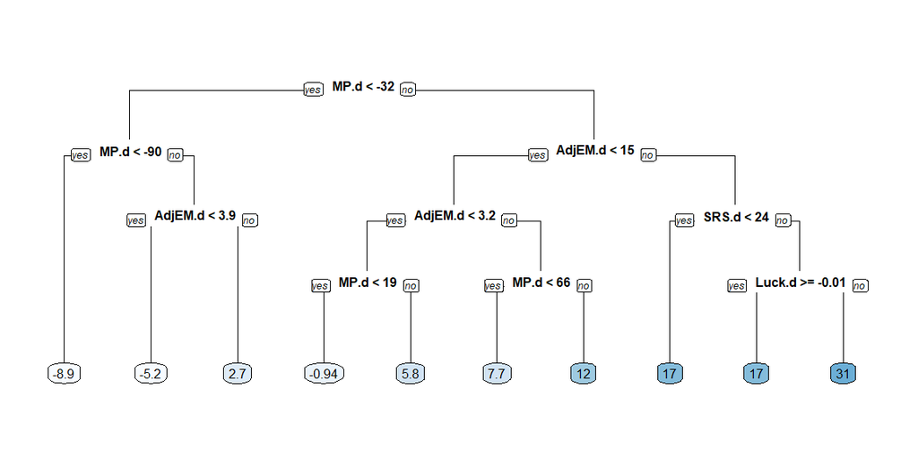

```r
# Plot the tree model
rpart.plot(x = NCAA_model, yesno = 2, type = 0, extra = 0)
```

Evaluate the Regression Tree Model

```r
# Generate predictions on a test set
pred <- predict(object = NCAA_model,   # model object
                newdata = NCAA_test %>% select(1:3,6,10:51,52))  # test dataset

# Compute the RMSE
rmse(actual = NCAA_test$result,
     predicted = pred)
```

```
## [1] 8.923955
```

Tuning the Model

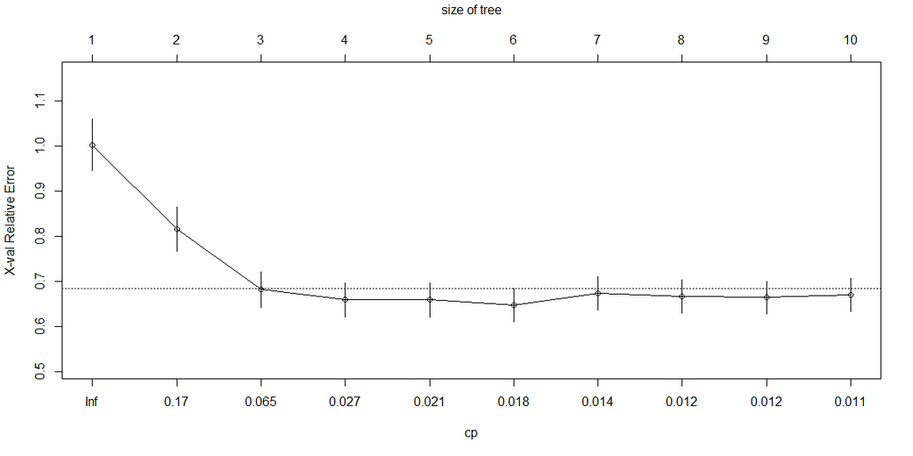

```r
# Plot the "CP Table"
plotcp(NCAA_model)
```

```r
# Print the "CP Table"
print(NCAA_model$cptable)
```

```
##            CP nsplit rel error    xerror       xstd
## 1  0.22217445      0 1.0000000 1.0023731 0.05742232
## 2  0.12517336      1 0.7778255 0.8161339 0.04925349
## 3  0.03336515      2 0.6526522 0.6821163 0.03975883
## 4  0.02120103      3 0.6192870 0.6594298 0.03794379
## 5  0.02093516      4 0.5980860 0.6591469 0.03765912
## 6  0.01506822      5 0.5771508 0.6474531 0.03657739
## 7  0.01236457      6 0.5620826 0.6735901 0.03720050
## 8  0.01229204      7 0.5497180 0.6661670 0.03691847
## 9  0.01189434      8 0.5374260 0.6640992 0.03658809
## 10 0.01000000      9 0.5255317 0.6697915 0.03701142
```

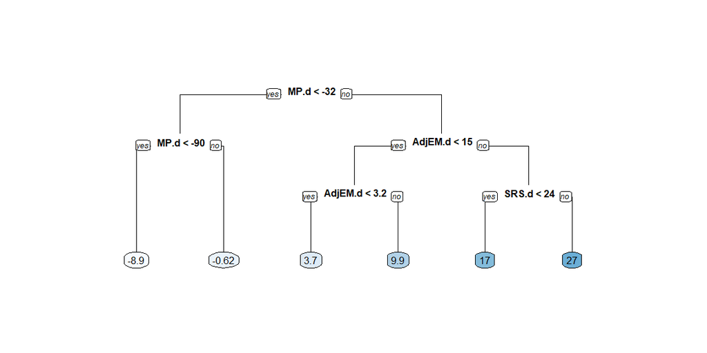

```r
# Retrieve optimal cp value based on cross-validated error
opt_index <- which.min(NCAA_model$cptable[, "xerror"])
cp_opt <- NCAA_model$cptable[opt_index, "CP"]

# Prune the model (to optimized cp value)
NCAA_model_opt <- prune(tree = NCAA_model, cp = cp_opt)

# Plot the optimized model
rpart.plot(x = NCAA_model_opt, yesno = 2, type = 0, extra = 0, roundint = FALSE)
```

Generate a grid of hyperparameter values

```r
# Establish a list of possible values for minsplit and maxdepth
minsplit <- seq(1, 4, 1)
maxdepth <- seq(1, 6, 1)

# Create a data frame containing all combinations
hyper_grid <- expand.grid(minsplit = minsplit, maxdepth = maxdepth)

# Check out the grid
head(hyper_grid)
```

```
##   minsplit maxdepth
## 1        1        1
## 2        2        1
## 3        3        1
## 4        4        1
## 5        1        2
## 6        2        2
```

```r
# Print the number of grid combinations
nrow(hyper_grid)
```

```
## [1] 24
```

Generate a grid of models

```r
# Number of potential models in the grid
num_models <- nrow(hyper_grid)

# Create an empty list to store models
NCAA_models <- list()

# Write a loop over the rows of hyper_grid to train the grid of models
for (i in 1:num_models) {

    # Get minsplit, maxdepth values at row i
    minsplit <- hyper_grid$minsplit[i]
    maxdepth <- hyper_grid$maxdepth[i]

    # Train a model and store in the list
    NCAA_models[[i]] <- rpart(formula = result ~ .,
                               data = NCAA_train%>% select(1:3,6,10:51,52),
                               method = "anova",
                               minsplit = minsplit,
                               maxdepth = maxdepth, model = TRUE)
}
```

Evaluate the Grid

```r
# Number of potential models in the grid
num_models <- length(NCAA_models)

# Create an empty vector to store RMSE values
rmse_values <- c()

# Write a loop over the models to compute validation RMSE
for (i in 1:num_models) {

    # Retrieve the i^th model from the list
    model <- NCAA_models[[i]]

    # Generate predictions on NCAA_valid
    pred <- predict(object = model,
                    newdata = NCAA_valid %>% select(1:3,6,10:51,52))

    # Compute validation RMSE and add to the
    rmse_values[i] <- rmse(actual = NCAA_valid$result,
                           predicted = pred)
}

# Identify the model with smallest validation set RMSE
best_model <- NCAA_models[[which.min(rmse_values)]]

# Print the model paramters of the best model
best_model$control
```

```
## $minsplit
## [1] 2
##
## $minbucket
## [1] 1
##
## $cp
## [1] 0.01
##
## $maxcompete
## [1] 4
##
## $maxsurrogate
## [1] 5
##
## $usesurrogate
## [1] 2
##
## $surrogatestyle
## [1] 0
##
## $maxdepth
## [1] 5
##
## $xval
## [1] 10
```

```r
# Compute test set RMSE on best_model
pred <- predict(object = best_model,
                newdata = NCAA_test %>% select(1:3,6,10:51,52))
rmse(actual = NCAA_test$result,
     predicted = pred)
```

```
## [1] 8.880161
```

Plot Results

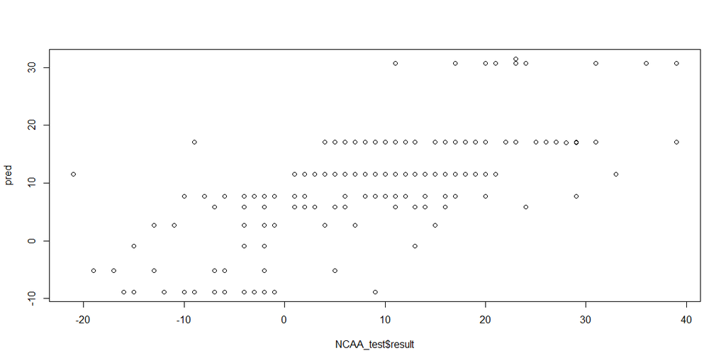

```r
plot(NCAA_test$result,pred)
```

## Bagging Trees

Train a Bootstraping Tree Model

```r
# Bagging is a randomized model, so let's set a seed (123) for reproducibility
set.seed(123)

# Train a bagged model
NCAA_model <- bagging(formula = result ~ .,
                        data = NCAA_train %>% select(1:3,6,10:51,52),
                        coob = TRUE)

# Print the model
print(NCAA_model)
```

```
##
## Bagging regression trees with 25 bootstrap replications
##
## Call: bagging.data.frame(formula = result ~ ., data = NCAA_train %>%
##     select(1:3, 6, 10:51, 52), coob = TRUE)
##
## Out-of-bag estimate of root mean squared error:  9.5502
```

Prediction and confusion matrix

```r
# Train a bagged model
NCAA_model <- bagging(formula = bresult ~ .,
                        data = NCAA_train %>% select(1:3,6,10:51,53),
                        coob = TRUE)

# Generate predicted classes using the model object
class_prediction <- predict(object = NCAA_model,
                            newdata = NCAA_test %>% select(1:3,6,10:51,53),
                            type = "class")         # return classification labels
# Print the predicted classes
print(class_prediction)
```

```
##   [1] F F F U F F F F F F F F F F F F U F F F U F F F F F U F F U U F F U F
##  [36] F F F F F F F F F F F F F U F U U F F U U U F F F F U F U F U F F F F
##  [71] U F U U F F F F U F F F U F F U F F F U F F U U F F F F F F F F U F U
## [106] U F F F F U F F F F F F F U F F F F F F F F F F F U F U F F F F F F F
## [141] F F F F F F F F F F F F F U F F F F F F U F F F F F F F U F U F F F F
## [176] U F
## Levels: F U
```

```r
# Calculate the confusion matrix for the test set
confusionMatrix(data = class_prediction,
                reference = NCAA_test$bresult)
```

```
## Confusion Matrix and Statistics
##
##           Reference
## Prediction   F   U
##          F 122  18
##          U   8  29
##
##                Accuracy : 0.8531
##                  95% CI : (0.7922, 0.9017)
##     No Information Rate : 0.7345
##     P-Value [Acc > NIR] : 0.0001139
##
##                   Kappa : 0.596
##
##  Mcnemar's Test P-Value : 0.0775562
##
##             Sensitivity : 0.9385
##             Specificity : 0.6170
##          Pos Pred Value : 0.8714
##          Neg Pred Value : 0.7838
##              Prevalence : 0.7345
##          Detection Rate : 0.6893
##    Detection Prevalence : 0.7910
##       Balanced Accuracy : 0.7777
##
##        'Positive' Class : F
##
```

Predict on a test set and compute AUC

```r
# Generate predictions on the test set
pred <- predict(object = NCAA_model,
                newdata = NCAA_test,
                type = "prob")

# `pred` is a matrix
class(pred)
```

```
## [1] "matrix"
```

```r
# Look at the pred format
head(pred)
```

```
##         F    U
## [1,] 0.96 0.04
## [2,] 1.00 0.00
## [3,] 0.68 0.32
## [4,] 0.24 0.76
## [5,] 1.00 0.00
## [6,] 0.92 0.08
```

```r
# Compute the AUC (`actual` must be a binary vector)
auc(actual = ifelse(NCAA_test$bresult == "F", 1, 0),
    predicted = pred[,"F"])
```

```
## [1] 0.8840426
```

```r
# A zero AUC (Area under the curve) means your predictions are completely wrong in every case

# A .5 AUC means your model is just as good as a random guess

# A 1 AUC means your model is perfect.
```

Cross-validate a bagged tree model in caret

```r
# Specify the training configuration
ctrl <- trainControl(method = "cv",     # Cross-validation
                     number = 5,        # 5 folds
                     classProbs = TRUE,                  # For AUC
                     summaryFunction = twoClassSummary)  # For AUC

# Cross validate the NCAA model using "treebag" method;
# Track AUC (Area under the ROC curve)
set.seed(1)  # for reproducibility
NCAA_caret_model <- train(bresult ~ .,
                            data = NCAA_train %>% select(1:3,6,10:51,53),
                            method = "treebag",
                            metric = "ROC",
                            trControl = ctrl)

# Look at the model object
print(NCAA_caret_model)
```

```
## Bagged CART
##
## 829 samples
##  46 predictor
##   2 classes: 'F', 'U'
##
## No pre-processing
## Resampling: Cross-Validated (5 fold)
## Summary of sample sizes: 663, 664, 663, 663, 663
## Resampling results:
##
##   ROC        Sens       Spec
##   0.8583637  0.9211349  0.574359
```

```r
# Inspect the contents of the model list
names(NCAA_caret_model)
```

```
##  [1] "method"       "modelInfo"    "modelType"    "results"
##  [5] "pred"         "bestTune"     "call"         "dots"
##  [9] "metric"       "control"      "finalModel"   "preProcess"
## [13] "trainingData" "resample"     "resampledCM"  "perfNames"
## [17] "maximize"     "yLimits"      "times"        "levels"
## [21] "terms"        "coefnames"    "contrasts"    "xlevels"
```

```r
# Print the CV AUC
NCAA_caret_model$results[,"ROC"]
```

```
## [1] 0.8583637
```

Generate predictions from the caret model Generate predictions on a test set for the caret model.

Instructions 100 XP First generate predictions on the NCAA_test data frame using the NCAA_caret_model object. After generating test set predictions, use the auc() function from the Metrics package to compute AUC.

```r
# Generate predictions on the test set
pred <- predict(object = NCAA_caret_model,
                newdata = NCAA_test %>% select(1:3,6,10:51,53),
                type = "prob")

# Compute the AUC (`actual` must be a binary (or 1/0 numeric) vector)
auc(actual = ifelse(NCAA_test$bresult == "F", 1, 0), predicted = pred[,"F"])
```

```
## [1] 0.9060556
```

```r
# Generate predicted classes using the model object
class_prediction <- predict(object = NCAA_model,
                            newdata = NCAA_test %>% select(1:3,6,10:51,53),
                            type = "class")         # return classification

# Calculate the confusion matrix for the test set
confusionMatrix(data = class_prediction,
                reference = NCAA_test$bresult)
```

```
## Confusion Matrix and Statistics
##
##           Reference
## Prediction   F   U
##          F 122  18
##          U   8  29
##
##                Accuracy : 0.8531
##                  95% CI : (0.7922, 0.9017)
##     No Information Rate : 0.7345
##     P-Value [Acc > NIR] : 0.0001139
##
##                   Kappa : 0.596
##
##  Mcnemar's Test P-Value : 0.0775562
##
##             Sensitivity : 0.9385
##             Specificity : 0.6170
##          Pos Pred Value : 0.8714
##          Neg Pred Value : 0.7838
##              Prevalence : 0.7345
##          Detection Rate : 0.6893
##    Detection Prevalence : 0.7910
##       Balanced Accuracy : 0.7777
##
##        'Positive' Class : F
##
```

## Random Forest

Train a Random Forest Model

```r
# Train a Random Forest
set.seed(1)  # for reproducibility
NCAA_model <- randomForest(formula = bresult ~ .,
                             data = NCAA_train %>% select(1,3,6,10:51,53))

# Print the model output
print(NCAA_model)
```

```
##
## Call:
##  randomForest(formula = bresult ~ ., data = NCAA_train %>% select(1,      3, 6, 10:51, 53))
##                Type of random forest: classification
##                      Number of trees: 500
## No. of variables tried at each split: 6
##
##         OOB estimate of  error rate: 13.15%
## Confusion matrix:
##     F   U class.error
## F 600  34  0.05362776
## U  75 120  0.38461538
```

Evaluate out-of-bag error

```r
# Grab OOB error matrix & take a look
err <- NCAA_model$err.rate
head(err)
```

```
##            OOB         F         U
## [1,] 0.2300000 0.1460177 0.4864865
## [2,] 0.2251521 0.1459459 0.4634146
## [3,] 0.2000000 0.1152174 0.4516129
## [4,] 0.2166428 0.1314286 0.4767442
## [5,] 0.2131367 0.1325088 0.4666667
## [6,] 0.2107969 0.1216216 0.4946237
```

```r
# Look at final OOB error rate (last row in err matrix)
oob_err <- err[nrow(err), "OOB"]
print(oob_err)
```

```
##       OOB
## 0.1314837
```

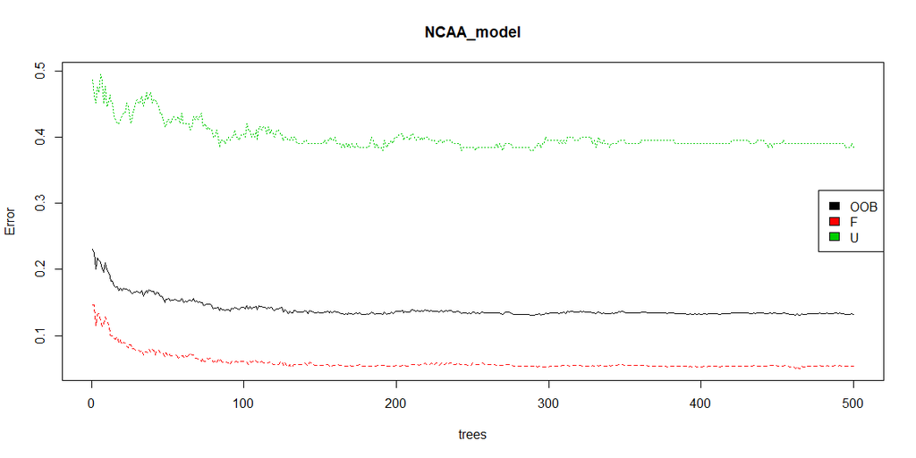

```r
# Plot the model trained in the previous exercise
plot(NCAA_model)

# Add a legend since it doesn't have one by default
legend(x = "right",
       legend = colnames(err),
       fill = 1:ncol(err))
```

Evaluate model performance on a test set

```r
# Generate predicted classes using the model object
class_prediction <- predict(object = NCAA_model,  # model object
                            newdata = NCAA_test %>% select(1,3,6,10:51,53),  # test dataset
                            type = "class")         # return classification labels

# Calculate the confusion matrix for the test set
cm <- confusionMatrix(data = class_prediction,          # predicted classes
                      reference = NCAA_test$bresult)  # actual classes
print(cm)
```

```
## Confusion Matrix and Statistics
##
##           Reference
## Prediction   F   U
##          F 127  23
##          U   3  24
##
##                Accuracy : 0.8531
##                  95% CI : (0.7922, 0.9017)
##     No Information Rate : 0.7345
##     P-Value [Acc > NIR] : 0.0001139
##
##                   Kappa : 0.5642
##
##  Mcnemar's Test P-Value : 0.0001944
##
##             Sensitivity : 0.9769
##             Specificity : 0.5106
##          Pos Pred Value : 0.8467
##          Neg Pred Value : 0.8889
##              Prevalence : 0.7345
##          Detection Rate : 0.7175
##    Detection Prevalence : 0.8475
##       Balanced Accuracy : 0.7438
##
##        'Positive' Class : F
##
```

```r
# Compare test set accuracy to OOB accuracy
paste0("Test Accuracy: ", cm$overall[1])
```

```
## [1] "Test Accuracy: 0.853107344632768"
```

```r
paste0("OOB Accuracy: ", 1 - oob_err)
```

```
## [1] "OOB Accuracy: 0.868516284680338"
```

Evaluate test set AUC

```r
# Generate predictions on the test set
pred <- predict(object = NCAA_model,
                newdata = NCAA_test %>% select(1,3,6,10:51,53),
                type = "prob")

# `pred` is a matrix
class(pred)
```

```
## [1] "matrix" "votes"
```

```r
# Look at the pred format
head(pred)
```

```
##        F     U
## 15 0.958 0.042
## 17 0.892 0.108
## 20 0.886 0.114
## 35 0.190 0.810
## 37 0.966 0.034
## 39 0.950 0.050
```

```r
# Compute the AUC (`actual` must be a binary 1/0 numeric vector)
auc(actual = ifelse(NCAA_test$bresult == "F", 1, 0),
    predicted = pred[,"F"])
```

```
## [1] 0.9260229
```

Tuning a Random Forest via mtry

```r
# Execute the tuning process
set.seed(1)
res <- tuneRF(x = subset(NCAA_train %>% select(1,3,6,10:51,53), select = -bresult), y = NCAA_train$bresult, ntreeTry = 500)
```

```
## mtry = 6  OOB error = 13.15%
## Searching left ...
## mtry = 3     OOB error = 13.39%
## -0.01834862 0.05
## Searching right ...
## mtry = 12    OOB error = 12.91%
## 0.01834862 0.05
```

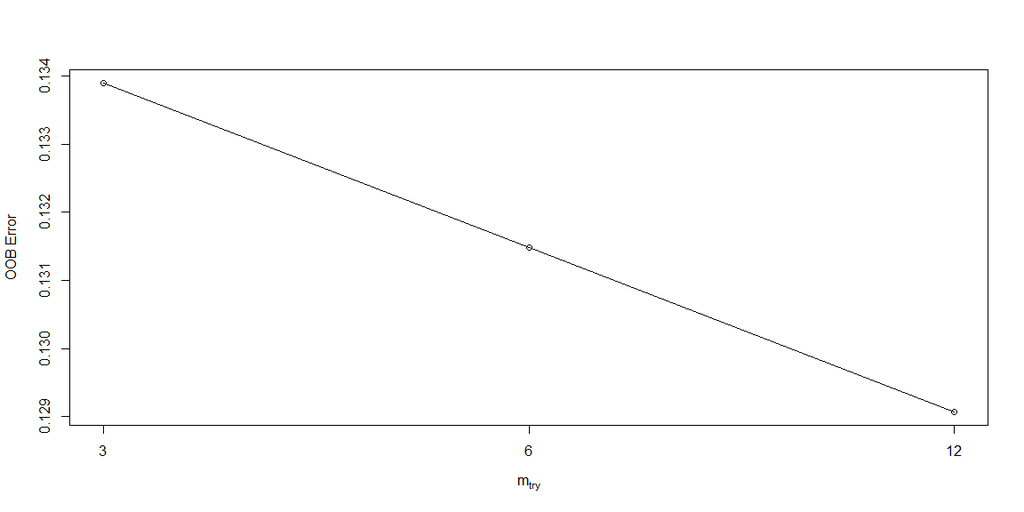

```r
# Look at results
print(res)
```

```
##        mtry  OOBError
## 3.OOB     3 0.1338963
## 6.OOB     6 0.1314837
## 12.OOB   12 0.1290712
```

```r
# Find the mtry value that minimizes OOB Error
mtry_opt <- res[,"mtry"][which.min(res[,"OOBError"])]
print(mtry_opt)
```

```
## 12.OOB
##     12
```

```r
# If you just want to return the best RF model (rather than results)
# you can set `doBest = TRUE` in `tuneRF()` to return the best RF model
# instead of a set performance matrix.
```

Tuning a Random Forest via tree depth In Chapter 2, we created a manual grid of hyperparameters using the expand.grid() function and wrote code that trained and evaluated the models of the grid in a loop. In this exercise, you will create a grid of mtry, nodesize and sampsize values. In this example, we will identify the “best model” based on OOB error. The best model is defined as the model from our grid which minimizes OOB error.

Keep in mind that there are other ways to select a best model from a grid, such as choosing the best model based on validation AUC. However, for this exercise, we will use the built-in OOB error calculations instead of using a separate validation set.

Instructions 100 XP Create a grid of mtry, nodesize and sampsize values. Write a simple loop to train all the models and choose the best one based on OOB error. Print the set of hyperparameters which produced the best model.

```r
# Establish a list of possible values for mtry, nodesize and sampsize
mtry <- seq(4, ncol(NCAA_train %>% select(1,3,6,10:51,53)) * 0.8, 2)
nodesize <- seq(3, 8, 2)
sampsize <- nrow(NCAA_train) * c(0.7, 0.8)

# Create a data frame containing all combinations
hyper_grid <- expand.grid(mtry = mtry, nodesize = nodesize, sampsize = sampsize)

# Create an empty vector to store OOB error values
oob_err <- c()

# Write a loop over the rows of hyper_grid to train the grid of models
for (i in 1:nrow(hyper_grid)) {

    # Train a Random Forest model
    model <- randomForest(formula = bresult ~ .,
                          data = NCAA_train %>% select(1,3,6,10:51,53),
                          mtry = hyper_grid$mtry[i],
                          nodesize = hyper_grid$nodesize[i],
                          sampsize = hyper_grid$sampsize[i])

    # Store OOB error for the model
    oob_err[i] <- model$err.rate[nrow(model$err.rate), "OOB"]
}

# Identify optimal set of hyperparmeters based on OOB error
opt_i <- which.min(oob_err)
print(hyper_grid[opt_i,])
```

```
##   mtry nodesize sampsize
## 1    4        3    580.3
```